# Predicting wine quality

The goal of this notebook is to train and evaluate different models on the Wine Quality Dataset.

## Report

### Models

We analyze the performance of four models with different structures, namely:

- Logistic regression,
- Random forest,
- XGBoost,
- TabPFN

### Data

The Wine Quality Dataset ([source](https://github.com/adrianstando/imbalanced-benchmarking-set/blob/main/datasets/wine_quality.csv)) served as the training and evaluation foundation for all the models discussed. Before running the code , ensure that you've downloaded the dataset and placed the CSV file in the same directory as this notebook.

Input variables (based on physicochemical tests):

- fixed acidity
- volatile acidity,
- citric acid
- residual sugar
- chlorides
- free sulfur dioxide
- total sulfur dioxide
- density
- pH
- sulphates
- alcohol

Output variable (based on sensory data):

- quality flag (-1 or 1)

### Results

Comparison of models in terms of ROC-AUC score:

- Logistic Regression: This basic model provided a foundational benchmark for performance, but was surpassed by more complex models.
- *Random Forest*: Demonstrated superior performance, standing out as the top contender among all the models evaluated.
- XGBoost: While it outperformed logistic regression, it couldn't quite match the performance of Random Forest.
- TabPFN: This model notably outshines both logistic regression and XGBoost. However, it falls marginally short of the results from Random Forest.

It's also worth noting that the use of SMOTE consistently led to a decline in ROC-AUC performance across all models.

[figure not shown]

## Appendix

### Imports

```python
import numpy as np
import pandas as pd
import seaborn as sns
from matplotlib import pyplot as plt
from sklearn.metrics import confusion_matrix
from sklearn.model_selection import train_test_split

from sklearn.linear_model import LogisticRegression
from sklearn.ensemble import RandomForestClassifier
from tabpfn import TabPFNClassifier
from xgboost import XGBClassifier

from imblearn.over_sampling import SMOTE

from sklearn.metrics import roc_curve, roc_auc_score, precision_score, recall_score, f1_score
```

### Load dataset

```python
TARGET_COL = 'is_good'

cols = [
    'fixed acidity',
    'volatile acidity',
    'citric acid',
    'residual sugar',
    'chlorides',
    'free sulfur dioxide',
    'total sulfur dioxide',
    'density',
    'pH',
    'sulphates',
    'alcohol',
    TARGET_COL
]

df = pd.read_csv('wine_quality.csv', header=0, names=cols)

print(f'Number of rows: {len(df)}')
df.head()
```

```
Number of rows: 4898
```

|  | fixed acidity | volatile acidity | citric acid | residual sugar | chlorides | free sulfur dioxide | total sulfur dioxide | density | pH | sulphates | alcohol | is_good |
| --- | --- | --- | --- | --- | --- | --- | --- | --- | --- | --- | --- | --- |
| 0 | 7.0 | 0.27 | 0.36 | 20.7 | 0.045 | 45.0 | 170.0 | 1.0010 | 3.00 | 0.45 | 8.8 | -1 |
| 1 | 6.3 | 0.30 | 0.34 | 1.6 | 0.049 | 14.0 | 132.0 | 0.9940 | 3.30 | 0.49 | 9.5 | -1 |
| 2 | 8.1 | 0.28 | 0.40 | 6.9 | 0.050 | 30.0 | 97.0 | 0.9951 | 3.26 | 0.44 | 10.1 | -1 |
| 3 | 7.2 | 0.23 | 0.32 | 8.5 | 0.058 | 47.0 | 186.0 | 0.9956 | 3.19 | 0.40 | 9.9 | -1 |
| 4 | 7.2 | 0.23 | 0.32 | 8.5 | 0.058 | 47.0 | 186.0 | 0.9956 | 3.19 | 0.40 | 9.9 | -1 |

### Class distribution

```
ratio = 25.77:1
```

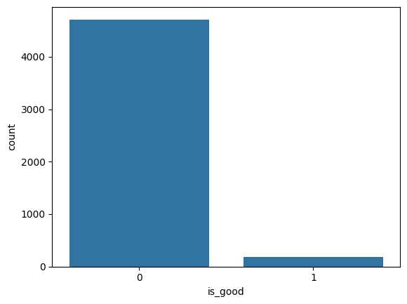

```python
df['is_good'] = df['is_good'].replace(-1, 0)

sns.countplot(df, x=TARGET_COL)

zeros_count = sum(df[TARGET_COL] == 0)
ones_count = sum(df[TARGET_COL] == 1)

ratio = zeros_count / ones_count
print(f'ratio = {ratio:.2f}:1')
```

### Corellations

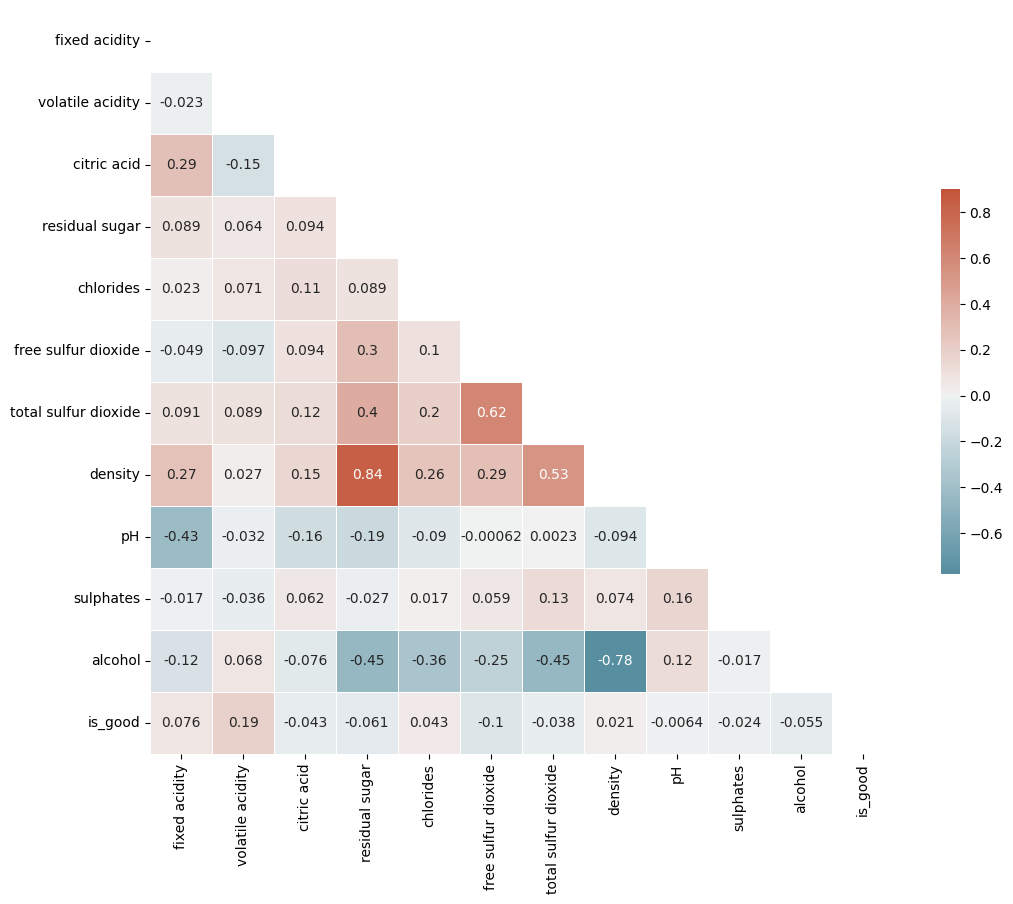

```python
corr = df.corr()
mask = np.triu(np.ones_like(corr, dtype=bool))

fig, ax = plt.subplots(figsize=(12, 10))
cmap = sns.diverging_palette(220, 20, as_cmap=True)
sns.heatmap(corr, mask=mask, cmap=cmap, vmax=0.9, center=0,
            square=True, linewidths=.5, cbar_kws={"shrink": .5}, annot=True)
```

Some variables are strongly correlacted, i.e. density and residual sugar or density ans alcohol.  
However, the target variable 'is_good' has weak correlations, the strongest being with volatile acidity and free sulfur dioxide (0.19 and -0.1 respectively)

### Evaluation

#### Train-test split

```python
X = df.drop(TARGET_COL, axis=1)
y = df[TARGET_COL]

X_train, X_test, y_train, y_test = train_test_split(X, y, test_size=0.2, stratify=y,random_state=42)

print("Number of samples in training set:", len(X_train))
print("Number of samples in test set:", len(X_test))
```

```
Number of samples in training set: 3918
Number of samples in test set: 980
```

#### Oversampling

```
ratio = 1.00:1
```

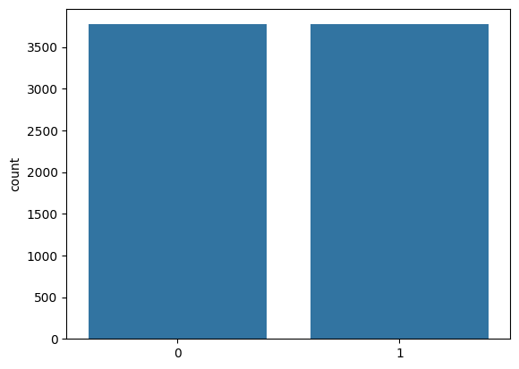

```python
sm = SMOTE(random_state=42)
X_train_sm, y_train_sm = sm.fit_resample(X_train, y_train.ravel())

sns.countplot(x=y_train_sm)

ratio = sum(y_train_sm == 0) / sum(y_train_sm == 1)
print(f'ratio = {ratio:.2f}:1')
```

#### Metrics

- ROC AUC score
- Precision
- Recall
- F1

```python
def calculate_metrics(y_true, y_pred_prob, threshold=0.5):
    y_pred_labels = [1 if prob > threshold else 0 for prob in y_pred_prob]

    auc = roc_auc_score(y_true, y_pred_prob)
    precision = precision_score(y_true, y_pred_labels)
    recall = recall_score(y_true, y_pred_labels)
    f1 = f1_score(y_true, y_pred_labels)

    results = {
        'ROC AUC Score': auc,
        'Precision': precision,
        'Recall': recall,
        'F1 Score': f1
    }

    show_plots(y_test, y_pred_labels, y_pred_prob)

    return results


def show_plots(y_true, y_pred, y_pred_prob):
    cm = confusion_matrix(y_test, y_pred)
    cm_df = pd.DataFrame(cm, index=['Actual Negative', 'Actual Positive'], columns=['Predicted Negative', 'Predicted Positive'])


    fig, (ax1, ax2) = plt.subplots(1, 2, figsize=(15, 6))

    # Confusion Matrix
    sns.heatmap(cm_df, annot=True, cmap='Blues', fmt='g', ax=ax1)
    ax1.set_title('Confusion Matrix')
    ax1.set_ylabel('Actual Values')
    ax1.set_xlabel('Predicted Values')

    # ROC Curve
    fpr, tpr, thresholds = roc_curve(y_test, y_pred_prob)
    ax2.plot(fpr, tpr, color='blue', label='ROC curve')
    ax2.plot([0, 1], [0, 1], 'r--')
    ax2.set_xlim([0.0, 1.0])
    ax2.set_ylim([0.0, 1.05])
    ax2.set_xlabel('False Positive Rate')
    ax2.set_ylabel('True Positive Rate')
    ax2.set_title('Receiver Operating Characteristic (ROC) Curve')
    ax2.legend(loc="lower right")
    plt.show()
```

```python
def train_eval_model(model, X_train, y_train, X_test, y_test):
    kwargs = {'overwrite_warning': True} if isinstance(model, TabPFNClassifier) else {}
    model.fit(X_train, y_train, **kwargs)
    y_pred_prob = model.predict_proba(X_test)[:, 1]
    results = calculate_metrics(y_test, y_pred_prob, threshold=0.5)
    return results, y_pred_prob

model_probs = {}

def print_model_eval(model_name, model, model_probs=model_probs, X_train=X_train, y_train=y_train, X_test=X_test, y_test=y_test, X_train_sm=X_train_sm, y_train_sm=y_train_sm):
    print(f"{model_name}:")
    metrics, y_pred_prob = train_eval_model(model, X_train, y_train, X_test, y_test)
    model_probs[model_name] = y_pred_prob
    for metric_name, metric_value in metrics.items():
        print(f"{metric_name}: {metric_value:.4f}")

    if X_train_sm is not None and y_train_sm is not None:
        model_name += ' with SMOTE'
        print(f"\n\n{model_name}:")
        metrics_sm, y_pred_prob = train_eval_model(model, X_train_sm, y_train_sm, X_test, y_test)
        # model_probs[model_name] = y_pred_prob
        for metric_name, metric_value in metrics_sm.items():
            print(f"{metric_name}: {metric_value:.4f}")
```

### Logistic regression

```
Logistic regression:
```

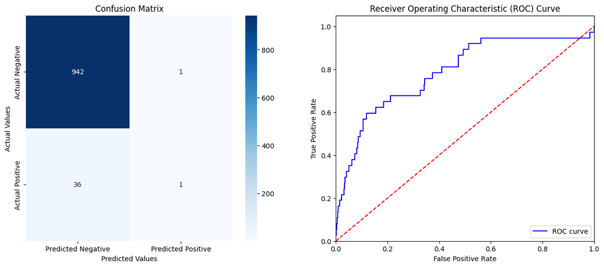

```
ROC AUC Score: 0.7861
Precision: 0.5000
Recall: 0.0270
F1 Score: 0.0513


Logistic regression with SMOTE:
```

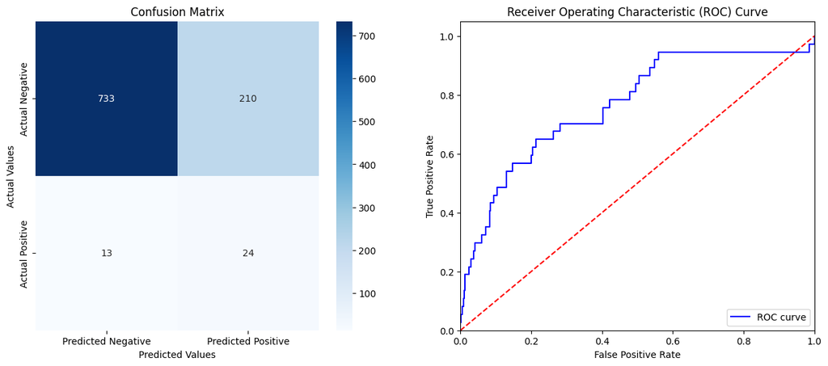

```
ROC AUC Score: 0.7660
Precision: 0.1026
Recall: 0.6486
F1 Score: 0.1771
```

```python
model_name = "Logistic regression"
model = LogisticRegression(max_iter=1000, random_state=42)

print_model_eval(model_name, model)
```

### Random Forest

```
Random Forest:
```

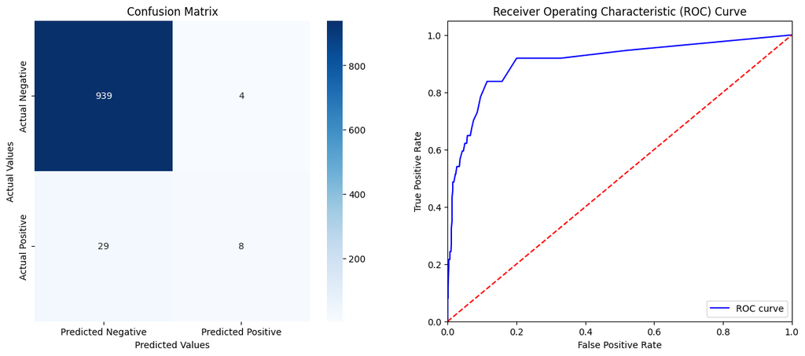

```
ROC AUC Score: 0.9070
Precision: 0.6667
Recall: 0.2162
F1 Score: 0.3265


Random Forest with SMOTE:
```

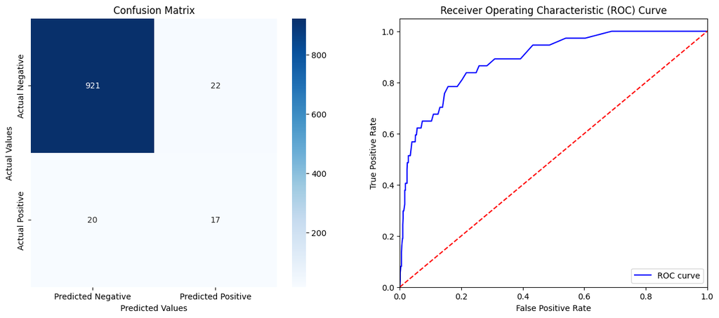

```
ROC AUC Score: 0.8896
Precision: 0.4359
Recall: 0.4595
F1 Score: 0.4474
```

```python
model_name = "Random Forest"
model = RandomForestClassifier()

print_model_eval(model_name, model)
```

The RandomForest achieves very high ROC-AUC score and outperforms the logistic regression. Using SMOTE appears to reduce the ROC-AUC performance.

### XGBoost

```
XGBoost:
```

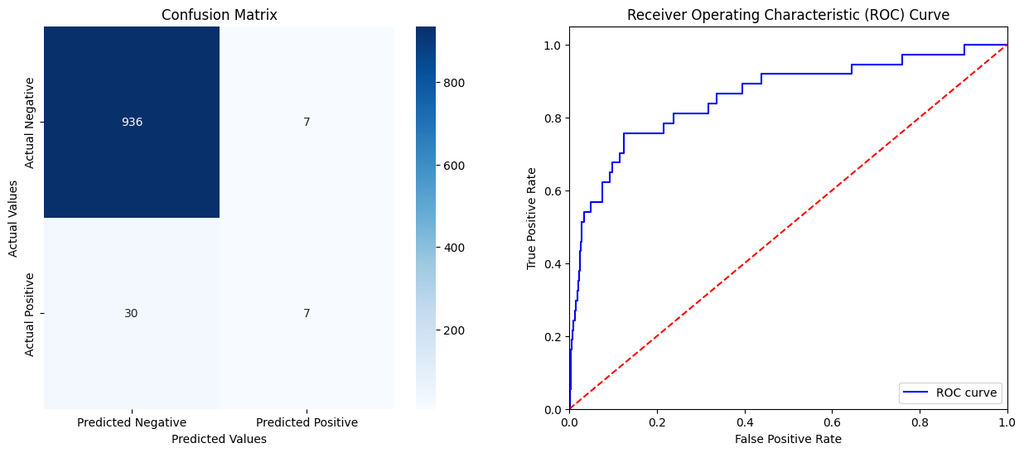

```
ROC AUC Score: 0.8572
Precision: 0.5000
Recall: 0.1892
F1 Score: 0.2745


XGBoost with SMOTE:
```

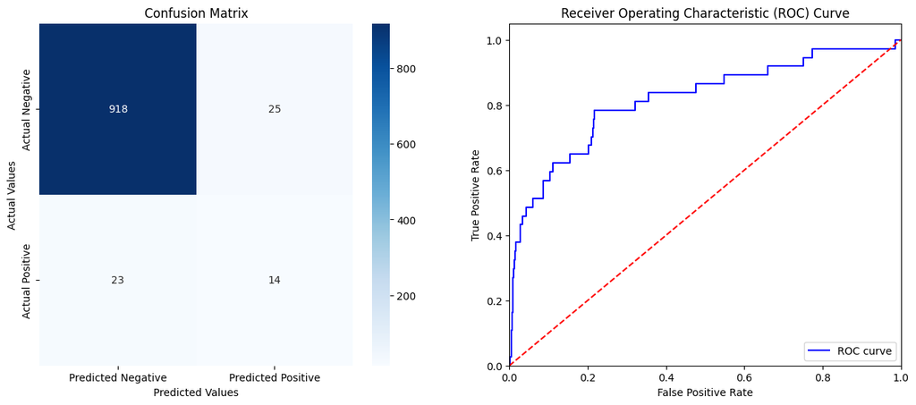

```
ROC AUC Score: 0.8168
Precision: 0.3590
Recall: 0.3784
F1 Score: 0.3684
```

```python
model_name = "XGBoost"
model = XGBClassifier()

print_model_eval(model_name, model)
```

XGBoost surpasses logistic regression in terms of the ROC-AUC score, yet it lags behind Random Forest. Implementing SMOTE seems to diminish the ROC-AUC results.

### TabPFN

The TabPFN is a neural network that learned to do tabular data prediction.

```
Loading model that can be used for inference only
Using a Transformer with 25.82 M parameters
TabPFN:
```

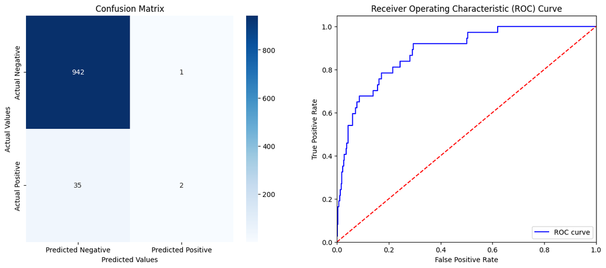

```
ROC AUC Score: 0.8835
Precision: 0.6667
Recall: 0.0541
F1 Score: 0.1000


TabPFN with SMOTE:
```

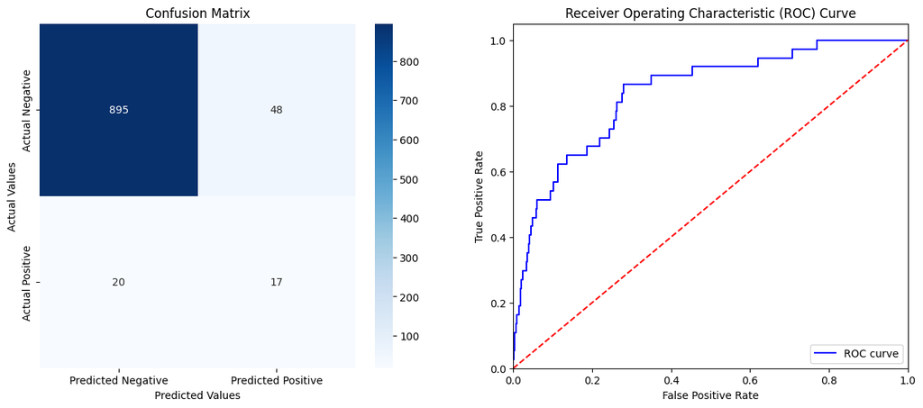

```
ROC AUC Score: 0.8400
Precision: 0.2615
Recall: 0.4595
F1 Score: 0.3333
```

```python
model_name = "TabPFN"
model = TabPFNClassifier()

print_model_eval(model_name, model)
```

TabPFN outperforms both logistic regression and xgboost based on the ROC-AUC score, but it trails slightly behind Random Forest. The introduction of SMOTE appears to negatively impact the ROC-AUC performance.

#### ROC curves

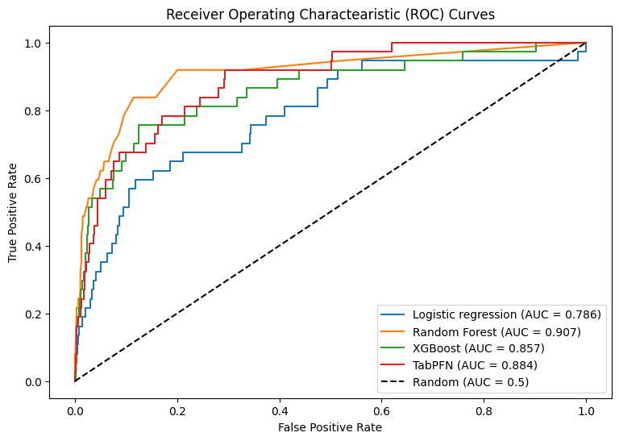

```python
plt.figure(figsize=(9, 6))

for model_name, y_pred_probs in model_probs.items():
    fpr, tpr, thresholds = roc_curve(y_test, y_pred_probs)
    roc_auc = roc_auc_score(y_test, y_pred_probs)
    plt.plot(fpr, tpr, label=f"{model_name} (AUC = {roc_auc:.3f})")

plt.plot([0, 1], [0, 1], 'k--', label="Random (AUC = 0.5)")

plt.title("Receiver Operating Charactearistic (ROC) Curves")
plt.xlabel("False Positive Rate")
plt.ylabel("True Positive Rate")

plt.legend(loc="lower right")
plt.savefig("images/roc_curves.png")
plt.show()
```

We can also see that oversampling the data with SMOTE in all cases decreased test roc-auc score.